# Developing Data Products Projects

Trent Lin  
Feb.22 2015

### Introduction

This is a simple Shiny app to preidct car's using miles per gallon(MPG) by (AM),(WT),and (hp).

- MPG: Miles/(US) gallon
- AM: Transmission Type (0 = automatic, 1 = manual)
- WT: Weight (1000 lb)
- hp: Gross horsepowr

### Regression Model

```
            Estimate Std. Error t value  Pr(>|t|)
(Intercept) 34.00288   2.642659  12.867 2.824e-13
amManual     2.08371   1.376420   1.514 1.413e-01
wt          -2.87858   0.904971  -3.181 3.574e-03
hp          -0.03748   0.009605  -3.902 5.464e-04
```

- MPG = as.numeric(am)*2.08371013-2.87857541*wt-0.03747873*hp+34.00287512
- This model explain 84% of variance in car's using miles per gallon

### Residuals & Diagostics

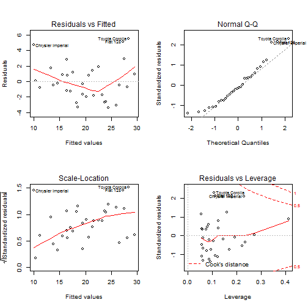

### conclusion

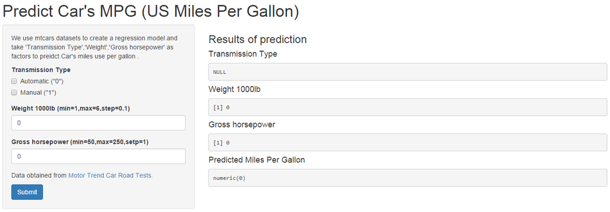

This is the screeshot of my shiny APP to predict car's using mile per gallon.If you are interesting it is avaiable on shinyapps.io [Visit shinyapps.io](http://trentlin.shinyapps.io/Project)